# Risk Factor Analysis

## Outcome Variable

**Outcome Variable:** wast_rec90d

## Predictor Variables

**Intervention Variable:** mhtcm

**Adjustment Set:**

- arm
- W_mage
- meducyrs
- feducyrs
- delta_W_mage
- delta_meducyrs
- delta_feducyrs

## Stratifying Variables

The analysis was stratified on these variable(s):

- agecat
- studyid
- country

## Data Summary

| agecat | studyid | country | mhtcm | wast_rec90d | n_cell | n |
| --- | --- | --- | --- | --- | --- | --- |
| 0-24 months | COHORTS | GUATEMALA | >=155 cm | 0 | 25 | 373 |
| 0-24 months | COHORTS | GUATEMALA | >=155 cm | 1 | 25 | 373 |
| 0-24 months | COHORTS | GUATEMALA | <151 cm | 0 | 144 | 373 |
| 0-24 months | COHORTS | GUATEMALA | <151 cm | 1 | 112 | 373 |
| 0-24 months | COHORTS | GUATEMALA | [151-155) cm | 0 | 37 | 373 |
| 0-24 months | COHORTS | GUATEMALA | [151-155) cm | 1 | 30 | 373 |
| 0-24 months | COHORTS | INDIA | >=155 cm | 0 | 143 | 700 |
| 0-24 months | COHORTS | INDIA | >=155 cm | 1 | 66 | 700 |
| 0-24 months | COHORTS | INDIA | <151 cm | 0 | 240 | 700 |
| 0-24 months | COHORTS | INDIA | <151 cm | 1 | 69 | 700 |
| 0-24 months | COHORTS | INDIA | [151-155) cm | 0 | 138 | 700 |
| 0-24 months | COHORTS | INDIA | [151-155) cm | 1 | 44 | 700 |
| 0-24 months | COHORTS | PHILIPPINES | >=155 cm | 0 | 108 | 1689 |
| 0-24 months | COHORTS | PHILIPPINES | >=155 cm | 1 | 213 | 1689 |
| 0-24 months | COHORTS | PHILIPPINES | <151 cm | 0 | 380 | 1689 |
| 0-24 months | COHORTS | PHILIPPINES | <151 cm | 1 | 553 | 1689 |
| 0-24 months | COHORTS | PHILIPPINES | [151-155) cm | 0 | 176 | 1689 |
| 0-24 months | COHORTS | PHILIPPINES | [151-155) cm | 1 | 259 | 1689 |
| 0-24 months | Guatemala BSC | GUATEMALA | >=155 cm | 0 | 1 | 32 |
| 0-24 months | Guatemala BSC | GUATEMALA | >=155 cm | 1 | 2 | 32 |
| 0-24 months | Guatemala BSC | GUATEMALA | <151 cm | 0 | 10 | 32 |
| 0-24 months | Guatemala BSC | GUATEMALA | <151 cm | 1 | 10 | 32 |
| 0-24 months | Guatemala BSC | GUATEMALA | [151-155) cm | 0 | 7 | 32 |
| 0-24 months | Guatemala BSC | GUATEMALA | [151-155) cm | 1 | 2 | 32 |
| 0-24 months | iLiNS-Zinc | BURKINA FASO | >=155 cm | 0 | 661 | 794 |
| 0-24 months | iLiNS-Zinc | BURKINA FASO | >=155 cm | 1 | 31 | 794 |
| 0-24 months | iLiNS-Zinc | BURKINA FASO | <151 cm | 0 | 30 | 794 |
| 0-24 months | iLiNS-Zinc | BURKINA FASO | <151 cm | 1 | 1 | 794 |
| 0-24 months | iLiNS-Zinc | BURKINA FASO | [151-155) cm | 0 | 68 | 794 |
| 0-24 months | iLiNS-Zinc | BURKINA FASO | [151-155) cm | 1 | 3 | 794 |

[output cut: 378 more lines]

The following strata were considered:

- agecat: 0-24 months, studyid: COHORTS, country: GUATEMALA
- agecat: 0-24 months, studyid: COHORTS, country: INDIA
- agecat: 0-24 months, studyid: COHORTS, country: PHILIPPINES
- agecat: 0-24 months, studyid: Guatemala BSC, country: GUATEMALA
- agecat: 0-24 months, studyid: iLiNS-Zinc, country: BURKINA FASO
- agecat: 0-24 months, studyid: JiVitA-3, country: BANGLADESH
- agecat: 0-24 months, studyid: Keneba, country: GAMBIA
- agecat: 0-24 months, studyid: LCNI-5, country: MALAWI
- agecat: 0-24 months, studyid: MAL-ED, country: BANGLADESH
- agecat: 0-24 months, studyid: MAL-ED, country: BRAZIL
- agecat: 0-24 months, studyid: MAL-ED, country: INDIA
- agecat: 0-24 months, studyid: MAL-ED, country: NEPAL
- agecat: 0-24 months, studyid: MAL-ED, country: PERU
- agecat: 0-24 months, studyid: MAL-ED, country: SOUTH AFRICA
- agecat: 0-24 months, studyid: MAL-ED, country: TANZANIA, UNITED REPUBLIC OF
- agecat: 0-24 months, studyid: NIH-Birth, country: BANGLADESH
- agecat: 0-24 months, studyid: NIH-Crypto, country: BANGLADESH
- agecat: 0-24 months, studyid: PROBIT, country: BELARUS
- agecat: 0-24 months, studyid: PROVIDE, country: BANGLADESH
- agecat: 0-24 months, studyid: SAS-CompFeed, country: INDIA
- agecat: 0-24 months, studyid: SAS-FoodSuppl, country: INDIA
- agecat: 0-24 months, studyid: TanzaniaChild2, country: TANZANIA, UNITED REPUBLIC OF
- agecat: 0-24 months, studyid: ZVITAMBO, country: ZIMBABWE
- agecat: 0-6 months, studyid: COHORTS, country: GUATEMALA
- agecat: 0-6 months, studyid: COHORTS, country: INDIA
- agecat: 0-6 months, studyid: COHORTS, country: PHILIPPINES
- agecat: 0-6 months, studyid: Guatemala BSC, country: GUATEMALA
- agecat: 0-6 months, studyid: JiVitA-3, country: BANGLADESH
- agecat: 0-6 months, studyid: Keneba, country: GAMBIA
- agecat: 0-6 months, studyid: LCNI-5, country: MALAWI
- agecat: 0-6 months, studyid: MAL-ED, country: BANGLADESH
- agecat: 0-6 months, studyid: MAL-ED, country: BRAZIL
- agecat: 0-6 months, studyid: MAL-ED, country: INDIA
- agecat: 0-6 months, studyid: MAL-ED, country: NEPAL
- agecat: 0-6 months, studyid: MAL-ED, country: PERU
- agecat: 0-6 months, studyid: MAL-ED, country: SOUTH AFRICA
- agecat: 0-6 months, studyid: MAL-ED, country: TANZANIA, UNITED REPUBLIC OF
- agecat: 0-6 months, studyid: NIH-Birth, country: BANGLADESH
- agecat: 0-6 months, studyid: NIH-Crypto, country: BANGLADESH
- agecat: 0-6 months, studyid: PROBIT, country: BELARUS
- agecat: 0-6 months, studyid: PROVIDE, country: BANGLADESH
- agecat: 0-6 months, studyid: SAS-CompFeed, country: INDIA
- agecat: 0-6 months, studyid: SAS-FoodSuppl, country: INDIA
- agecat: 0-6 months, studyid: TanzaniaChild2, country: TANZANIA, UNITED REPUBLIC OF
- agecat: 0-6 months, studyid: ZVITAMBO, country: ZIMBABWE
- agecat: 6-24 months, studyid: COHORTS, country: GUATEMALA
- agecat: 6-24 months, studyid: COHORTS, country: INDIA
- agecat: 6-24 months, studyid: COHORTS, country: PHILIPPINES
- agecat: 6-24 months, studyid: Guatemala BSC, country: GUATEMALA
- agecat: 6-24 months, studyid: iLiNS-Zinc, country: BURKINA FASO
- agecat: 6-24 months, studyid: JiVitA-3, country: BANGLADESH
- agecat: 6-24 months, studyid: Keneba, country: GAMBIA
- agecat: 6-24 months, studyid: LCNI-5, country: MALAWI
- agecat: 6-24 months, studyid: MAL-ED, country: BANGLADESH
- agecat: 6-24 months, studyid: MAL-ED, country: BRAZIL
- agecat: 6-24 months, studyid: MAL-ED, country: INDIA
- agecat: 6-24 months, studyid: MAL-ED, country: NEPAL
- agecat: 6-24 months, studyid: MAL-ED, country: PERU
- agecat: 6-24 months, studyid: MAL-ED, country: SOUTH AFRICA
- agecat: 6-24 months, studyid: MAL-ED, country: TANZANIA, UNITED REPUBLIC OF
- agecat: 6-24 months, studyid: NIH-Birth, country: BANGLADESH
- agecat: 6-24 months, studyid: NIH-Crypto, country: BANGLADESH
- agecat: 6-24 months, studyid: PROBIT, country: BELARUS
- agecat: 6-24 months, studyid: PROVIDE, country: BANGLADESH
- agecat: 6-24 months, studyid: SAS-CompFeed, country: INDIA
- agecat: 6-24 months, studyid: SAS-FoodSuppl, country: INDIA
- agecat: 6-24 months, studyid: TanzaniaChild2, country: TANZANIA, UNITED REPUBLIC OF
- agecat: 6-24 months, studyid: ZVITAMBO, country: ZIMBABWE

### Dropped Strata

Some strata were dropped due to rare outcomes:

- agecat: 0-24 months, studyid: Guatemala BSC, country: GUATEMALA
- agecat: 0-24 months, studyid: iLiNS-Zinc, country: BURKINA FASO
- agecat: 0-24 months, studyid: LCNI-5, country: MALAWI
- agecat: 0-24 months, studyid: MAL-ED, country: BANGLADESH
- agecat: 0-24 months, studyid: MAL-ED, country: BRAZIL
- agecat: 0-24 months, studyid: MAL-ED, country: NEPAL
- agecat: 0-24 months, studyid: MAL-ED, country: PERU
- agecat: 0-24 months, studyid: MAL-ED, country: SOUTH AFRICA
- agecat: 0-24 months, studyid: MAL-ED, country: TANZANIA, UNITED REPUBLIC OF
- agecat: 0-24 months, studyid: PROBIT, country: BELARUS
- agecat: 0-24 months, studyid: SAS-FoodSuppl, country: INDIA
- agecat: 0-6 months, studyid: Guatemala BSC, country: GUATEMALA
- agecat: 0-6 months, studyid: LCNI-5, country: MALAWI
- agecat: 0-6 months, studyid: MAL-ED, country: BANGLADESH
- agecat: 0-6 months, studyid: MAL-ED, country: BRAZIL
- agecat: 0-6 months, studyid: MAL-ED, country: NEPAL
- agecat: 0-6 months, studyid: MAL-ED, country: PERU
- agecat: 0-6 months, studyid: MAL-ED, country: SOUTH AFRICA
- agecat: 0-6 months, studyid: MAL-ED, country: TANZANIA, UNITED REPUBLIC OF
- agecat: 0-6 months, studyid: NIH-Crypto, country: BANGLADESH
- agecat: 0-6 months, studyid: PROBIT, country: BELARUS
- agecat: 0-6 months, studyid: SAS-FoodSuppl, country: INDIA
- agecat: 6-24 months, studyid: COHORTS, country: GUATEMALA
- agecat: 6-24 months, studyid: COHORTS, country: INDIA
- agecat: 6-24 months, studyid: Guatemala BSC, country: GUATEMALA
- agecat: 6-24 months, studyid: iLiNS-Zinc, country: BURKINA FASO
- agecat: 6-24 months, studyid: JiVitA-3, country: BANGLADESH
- agecat: 6-24 months, studyid: LCNI-5, country: MALAWI
- agecat: 6-24 months, studyid: MAL-ED, country: BANGLADESH
- agecat: 6-24 months, studyid: MAL-ED, country: BRAZIL
- agecat: 6-24 months, studyid: MAL-ED, country: NEPAL
- agecat: 6-24 months, studyid: MAL-ED, country: PERU
- agecat: 6-24 months, studyid: MAL-ED, country: SOUTH AFRICA
- agecat: 6-24 months, studyid: MAL-ED, country: TANZANIA, UNITED REPUBLIC OF
- agecat: 6-24 months, studyid: NIH-Crypto, country: BANGLADESH
- agecat: 6-24 months, studyid: PROBIT, country: BELARUS
- agecat: 6-24 months, studyid: SAS-FoodSuppl, country: INDIA
- agecat: 6-24 months, studyid: ZVITAMBO, country: ZIMBABWE

## Methods Detail

We’re interested in the causal parameters $E[Y_a]$ for all values of $a \in \mathcal{A}$. These parameters represent the mean outcome if, possibly contrary to fact, we intervened to set all units to have $A=a$. Under the randomization and positivity assumptions, these are identified by the statistical parameters $\psi_a=E_W[E_{Y|A,W}(Y|A=a,W)]$. In addition, we’re interested in the mean of $Y$, $E[Y]$ under no intervention (the observed mean). We will estimate these parameters by using SuperLearner to fit the relevant likelihood factors – $E_{Y|A,W}(Y|A=a,W)$ and $p(A=a|W)$, and then updating our likelihood fit using a joint TMLE.

For unadjusted analyses ($W=\{\}$), initial likelihoods were estimated using Lrnr_glm to estimate the simple $E(Y|A)$ and Lrnr_mean to estimate $p(A)$. For adjusted analyses, a small library containing Lrnr_glmnet, Lrnr_xgboost, and Lrnr_mean was used.

Having estimated these parameters, we will then use the delta method to estimate relative risks and attributable risks relative to a prespecified baseline level of $A$.

# Results Detail

## Results Plots

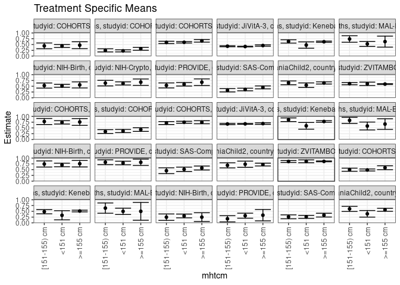

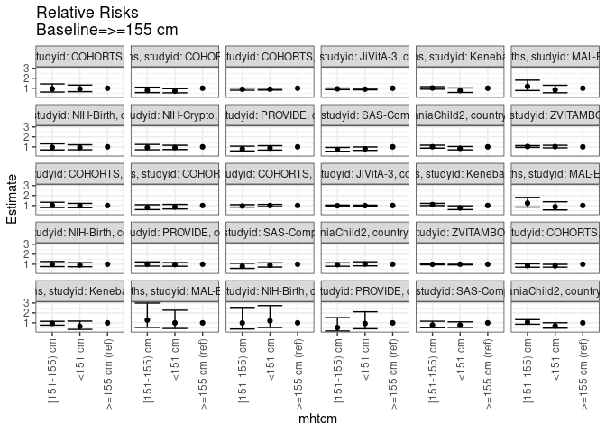

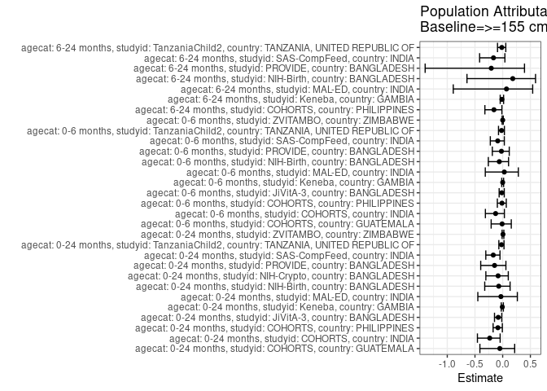

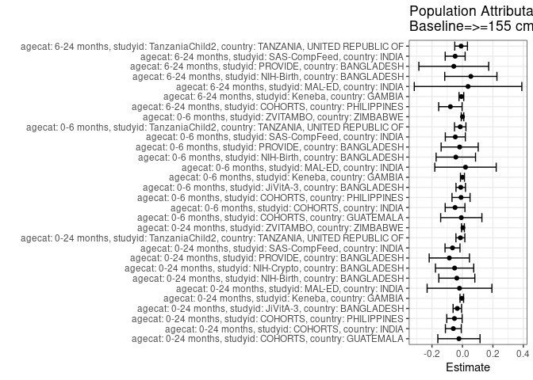

## Results Table

### Parameter: TSM

| agecat | studyid | country | intervention_level | baseline_level | estimate | ci_lower | ci_upper |
| --- | --- | --- | --- | --- | --- | --- | --- |
| 0-24 months | COHORTS | GUATEMALA | >=155 cm | NA | 0.4707893 | 0.3221240 | 0.6194546 |
| 0-24 months | COHORTS | GUATEMALA | <151 cm | NA | 0.4369806 | 0.3737225 | 0.5002387 |
| 0-24 months | COHORTS | GUATEMALA | [151-155) cm | NA | 0.4414137 | 0.3174626 | 0.5653649 |
| 0-24 months | COHORTS | INDIA | >=155 cm | NA | 0.3155209 | 0.2524056 | 0.3786361 |
| 0-24 months | COHORTS | INDIA | <151 cm | NA | 0.2261280 | 0.1796761 | 0.2725800 |
| 0-24 months | COHORTS | INDIA | [151-155) cm | NA | 0.2472592 | 0.1791124 | 0.3154060 |
| 0-24 months | COHORTS | PHILIPPINES | >=155 cm | NA | 0.6592584 | 0.6031452 | 0.7153715 |
| 0-24 months | COHORTS | PHILIPPINES | <151 cm | NA | 0.5962547 | 0.5640888 | 0.6284206 |
| 0-24 months | COHORTS | PHILIPPINES | [151-155) cm | NA | 0.5913341 | 0.5408068 | 0.6418615 |
| 0-24 months | JiVitA-3 | BANGLADESH | >=155 cm | NA | 0.4563384 | 0.4262484 | 0.4864284 |
| 0-24 months | JiVitA-3 | BANGLADESH | <151 cm | NA | 0.4125328 | 0.3981349 | 0.4269307 |
| 0-24 months | JiVitA-3 | BANGLADESH | [151-155) cm | NA | 0.4265765 | 0.4039739 | 0.4491791 |
| 0-24 months | Keneba | GAMBIA | >=155 cm | NA | 0.6194079 | 0.5917942 | 0.6470217 |
| 0-24 months | Keneba | GAMBIA | <151 cm | NA | 0.4765157 | 0.3389121 | 0.6141193 |
| 0-24 months | Keneba | GAMBIA | [151-155) cm | NA | 0.6341520 | 0.5618487 | 0.7064553 |
| 0-24 months | MAL-ED | INDIA | >=155 cm | NA | 0.6260512 | 0.3873756 | 0.8647269 |
| 0-24 months | MAL-ED | INDIA | <151 cm | NA | 0.5257269 | 0.4171883 | 0.6342656 |
| 0-24 months | MAL-ED | INDIA | [151-155) cm | NA | 0.7385245 | 0.5982535 | 0.8787955 |
| 0-24 months | NIH-Birth | BANGLADESH | >=155 cm | NA | 0.5570805 | 0.4260694 | 0.6880917 |
| 0-24 months | NIH-Birth | BANGLADESH | <151 cm | NA | 0.5153647 | 0.4517608 | 0.5789686 |
| 0-24 months | NIH-Birth | BANGLADESH | [151-155) cm | NA | 0.5292228 | 0.4185219 | 0.6399237 |
| 0-24 months | NIH-Crypto | BANGLADESH | >=155 cm | NA | 0.6760988 | 0.5389510 | 0.8132466 |
| 0-24 months | NIH-Crypto | BANGLADESH | <151 cm | NA | 0.6215755 | 0.5530200 | 0.6901311 |
| 0-24 months | NIH-Crypto | BANGLADESH | [151-155) cm | NA | 0.6345981 | 0.5139155 | 0.7552806 |
| 0-24 months | PROVIDE | BANGLADESH | >=155 cm | NA | 0.6736413 | 0.5309416 | 0.8163409 |
| 0-24 months | PROVIDE | BANGLADESH | <151 cm | NA | 0.5854279 | 0.5086415 | 0.6622143 |
| 0-24 months | PROVIDE | BANGLADESH | [151-155) cm | NA | 0.5347755 | 0.4266245 | 0.6429265 |
| 0-24 months | SAS-CompFeed | INDIA | >=155 cm | NA | 0.4496113 | 0.3863895 | 0.5128332 |
| 0-24 months | SAS-CompFeed | INDIA | <151 cm | NA | 0.3591276 | 0.3025214 | 0.4157339 |
| 0-24 months | SAS-CompFeed | INDIA | [151-155) cm | NA | 0.3258051 | 0.2537330 | 0.3978771 |

[output cut: 60 more lines]

### Parameter: E(Y)

| agecat | studyid | country | intervention_level | baseline_level | estimate | ci_lower | ci_upper |
| --- | --- | --- | --- | --- | --- | --- | --- |
| 0-24 months | COHORTS | GUATEMALA | NA | NA | 0.4477212 | 0.3954919 | 0.4999504 |
| 0-24 months | COHORTS | INDIA | NA | NA | 0.2557143 | 0.2227697 | 0.2886589 |
| 0-24 months | COHORTS | PHILIPPINES | NA | NA | 0.6068680 | 0.5823645 | 0.6313715 |
| 0-24 months | JiVitA-3 | BANGLADESH | NA | NA | 0.4226585 | 0.4115120 | 0.4338051 |
| 0-24 months | Keneba | GAMBIA | NA | NA | 0.6152905 | 0.5899139 | 0.6406671 |
| 0-24 months | MAL-ED | INDIA | NA | NA | 0.6067416 | 0.5268346 | 0.6866486 |
| 0-24 months | NIH-Birth | BANGLADESH | NA | NA | 0.5201900 | 0.4695846 | 0.5707955 |
| 0-24 months | NIH-Crypto | BANGLADESH | NA | NA | 0.6245955 | 0.5705077 | 0.6786833 |
| 0-24 months | PROVIDE | BANGLADESH | NA | NA | 0.5874587 | 0.5306185 | 0.6442990 |
| 0-24 months | SAS-CompFeed | INDIA | NA | NA | 0.3844086 | 0.3477135 | 0.4211037 |
| 0-24 months | TanzaniaChild2 | TANZANIA, UNITED REPUBLIC OF | NA | NA | 0.6283688 | 0.5905159 | 0.6662217 |
| 0-24 months | ZVITAMBO | ZIMBABWE | NA | NA | 0.5959970 | 0.5774555 | 0.6145386 |
| 0-6 months | COHORTS | GUATEMALA | NA | NA | 0.7500000 | 0.6917133 | 0.8082867 |
| 0-6 months | COHORTS | INDIA | NA | NA | 0.3800425 | 0.3361595 | 0.4239255 |
| 0-6 months | COHORTS | PHILIPPINES | NA | NA | 0.7367021 | 0.7051294 | 0.7682749 |
| 0-6 months | JiVitA-3 | BANGLADESH | NA | NA | 0.6758591 | 0.6624976 | 0.6892206 |
| 0-6 months | Keneba | GAMBIA | NA | NA | 0.7781155 | 0.7468871 | 0.8093439 |
| 0-6 months | MAL-ED | INDIA | NA | NA | 0.6867470 | 0.5837430 | 0.7897510 |
| 0-6 months | NIH-Birth | BANGLADESH | NA | NA | 0.7130045 | 0.6535890 | 0.7724200 |
| 0-6 months | PROVIDE | BANGLADESH | NA | NA | 0.8000000 | 0.7425836 | 0.8574164 |
| 0-6 months | SAS-CompFeed | INDIA | NA | NA | 0.5228758 | 0.4664267 | 0.5793250 |
| 0-6 months | TanzaniaChild2 | TANZANIA, UNITED REPUBLIC OF | NA | NA | 0.7053571 | 0.6558827 | 0.7548316 |
| 0-6 months | ZVITAMBO | ZIMBABWE | NA | NA | 0.8577803 | 0.8416785 | 0.8738820 |
| 6-24 months | COHORTS | PHILIPPINES | NA | NA | 0.5026681 | 0.4688378 | 0.5364984 |
| 6-24 months | Keneba | GAMBIA | NA | NA | 0.5056295 | 0.4721671 | 0.5390918 |
| 6-24 months | MAL-ED | INDIA | NA | NA | 0.5368421 | 0.4223932 | 0.6512910 |
| 6-24 months | NIH-Birth | BANGLADESH | NA | NA | 0.3030303 | 0.2377927 | 0.3682679 |
| 6-24 months | PROVIDE | BANGLADESH | NA | NA | 0.2764228 | 0.1950773 | 0.3577682 |
| 6-24 months | SAS-CompFeed | INDIA | NA | NA | 0.2876712 | 0.2441703 | 0.3311721 |
| 6-24 months | TanzaniaChild2 | TANZANIA, UNITED REPUBLIC OF | NA | NA | 0.5582656 | 0.5057575 | 0.6107737 |

### Parameter: RR

| agecat | studyid | country | intervention_level | baseline_level | estimate | ci_lower | ci_upper |
| --- | --- | --- | --- | --- | --- | --- | --- |
| 0-24 months | COHORTS | GUATEMALA | >=155 cm | >=155 cm | 1.0000000 | 1.0000000 | 1.0000000 |
| 0-24 months | COHORTS | GUATEMALA | <151 cm | >=155 cm | 0.9281870 | 0.6555007 | 1.3143100 |
| 0-24 months | COHORTS | GUATEMALA | [151-155) cm | >=155 cm | 0.9376035 | 0.6143136 | 1.4310285 |
| 0-24 months | COHORTS | INDIA | >=155 cm | >=155 cm | 1.0000000 | 1.0000000 | 1.0000000 |
| 0-24 months | COHORTS | INDIA | <151 cm | >=155 cm | 0.7166817 | 0.5382161 | 0.9543241 |
| 0-24 months | COHORTS | INDIA | [151-155) cm | >=155 cm | 0.7836540 | 0.5571938 | 1.1021544 |
| 0-24 months | COHORTS | PHILIPPINES | >=155 cm | >=155 cm | 1.0000000 | 1.0000000 | 1.0000000 |
| 0-24 months | COHORTS | PHILIPPINES | <151 cm | >=155 cm | 0.9044325 | 0.8177292 | 1.0003290 |
| 0-24 months | COHORTS | PHILIPPINES | [151-155) cm | >=155 cm | 0.8969687 | 0.7950304 | 1.0119775 |
| 0-24 months | JiVitA-3 | BANGLADESH | >=155 cm | >=155 cm | 1.0000000 | 1.0000000 | 1.0000000 |
| 0-24 months | JiVitA-3 | BANGLADESH | <151 cm | >=155 cm | 0.9040063 | 0.8390238 | 0.9740217 |
| 0-24 months | JiVitA-3 | BANGLADESH | [151-155) cm | >=155 cm | 0.9347811 | 0.8589743 | 1.0172780 |
| 0-24 months | Keneba | GAMBIA | >=155 cm | >=155 cm | 1.0000000 | 1.0000000 | 1.0000000 |
| 0-24 months | Keneba | GAMBIA | <151 cm | >=155 cm | 0.7693083 | 0.5743970 | 1.0303594 |
| 0-24 months | Keneba | GAMBIA | [151-155) cm | >=155 cm | 1.0238035 | 0.9058944 | 1.1570593 |
| 0-24 months | MAL-ED | INDIA | >=155 cm | >=155 cm | 1.0000000 | 1.0000000 | 1.0000000 |
| 0-24 months | MAL-ED | INDIA | <151 cm | >=155 cm | 0.8397507 | 0.5439293 | 1.2964575 |
| 0-24 months | MAL-ED | INDIA | [151-155) cm | >=155 cm | 1.1796550 | 0.7701488 | 1.8069054 |
| 0-24 months | NIH-Birth | BANGLADESH | >=155 cm | >=155 cm | 1.0000000 | 1.0000000 | 1.0000000 |
| 0-24 months | NIH-Birth | BANGLADESH | <151 cm | >=155 cm | 0.9251170 | 0.7090671 | 1.2069966 |
| 0-24 months | NIH-Birth | BANGLADESH | [151-155) cm | >=155 cm | 0.9499933 | 0.6935319 | 1.3012916 |
| 0-24 months | NIH-Crypto | BANGLADESH | >=155 cm | >=155 cm | 1.0000000 | 1.0000000 | 1.0000000 |
| 0-24 months | NIH-Crypto | BANGLADESH | <151 cm | >=155 cm | 0.9193561 | 0.7294386 | 1.1587207 |
| 0-24 months | NIH-Crypto | BANGLADESH | [151-155) cm | >=155 cm | 0.9386174 | 0.7106193 | 1.2397673 |
| 0-24 months | PROVIDE | BANGLADESH | >=155 cm | >=155 cm | 1.0000000 | 1.0000000 | 1.0000000 |
| 0-24 months | PROVIDE | BANGLADESH | <151 cm | >=155 cm | 0.8690500 | 0.6769646 | 1.1156385 |
| 0-24 months | PROVIDE | BANGLADESH | [151-155) cm | >=155 cm | 0.7938580 | 0.5921266 | 1.0643173 |
| 0-24 months | SAS-CompFeed | INDIA | >=155 cm | >=155 cm | 1.0000000 | 1.0000000 | 1.0000000 |
| 0-24 months | SAS-CompFeed | INDIA | <151 cm | >=155 cm | 0.7987512 | 0.6467080 | 0.9865404 |
| 0-24 months | SAS-CompFeed | INDIA | [151-155) cm | >=155 cm | 0.7246371 | 0.5576203 | 0.9416782 |

[output cut: 60 more lines]

### Parameter: PAR

| agecat | studyid | country | intervention_level | baseline_level | estimate | ci_lower | ci_upper |
| --- | --- | --- | --- | --- | --- | --- | --- |
| 0-24 months | COHORTS | GUATEMALA | >=155 cm | NA | -0.0230682 | -0.1615759 | 0.1154396 |
| 0-24 months | COHORTS | INDIA | >=155 cm | NA | -0.0598066 | -0.1118370 | -0.0077761 |
| 0-24 months | COHORTS | PHILIPPINES | >=155 cm | NA | -0.0523904 | -0.1028198 | -0.0019610 |
| 0-24 months | JiVitA-3 | BANGLADESH | >=155 cm | NA | -0.0336799 | -0.0614688 | -0.0058910 |
| 0-24 months | Keneba | GAMBIA | >=155 cm | NA | -0.0041174 | -0.0158661 | 0.0076312 |
| 0-24 months | MAL-ED | INDIA | >=155 cm | NA | -0.0193096 | -0.2320034 | 0.1933841 |
| 0-24 months | NIH-Birth | BANGLADESH | >=155 cm | NA | -0.0368905 | -0.1551606 | 0.0813796 |
| 0-24 months | NIH-Crypto | BANGLADESH | >=155 cm | NA | -0.0515033 | -0.1771596 | 0.0741529 |
| 0-24 months | PROVIDE | BANGLADESH | >=155 cm | NA | -0.0861825 | -0.2183976 | 0.0460326 |
| 0-24 months | SAS-CompFeed | INDIA | >=155 cm | NA | -0.0652027 | -0.1143364 | -0.0160690 |
| 0-24 months | TanzaniaChild2 | TANZANIA, UNITED REPUBLIC OF | >=155 cm | NA | -0.0135065 | -0.0427310 | 0.0157180 |
| 0-24 months | ZVITAMBO | ZIMBABWE | >=155 cm | NA | 0.0032512 | -0.0062473 | 0.0127497 |
| 0-6 months | COHORTS | GUATEMALA | >=155 cm | NA | -0.0075758 | -0.1429684 | 0.1278169 |
| 0-6 months | COHORTS | INDIA | >=155 cm | NA | -0.0485021 | -0.1132922 | 0.0162881 |
| 0-6 months | COHORTS | PHILIPPINES | >=155 cm | NA | -0.0092813 | -0.0685004 | 0.0499378 |
| 0-6 months | JiVitA-3 | BANGLADESH | >=155 cm | NA | -0.0111583 | -0.0423142 | 0.0199975 |
| 0-6 months | Keneba | GAMBIA | >=155 cm | NA | 0.0000550 | -0.0130742 | 0.0131842 |
| 0-6 months | MAL-ED | INDIA | >=155 cm | NA | 0.0200803 | -0.1814975 | 0.2216581 |
| 0-6 months | NIH-Birth | BANGLADESH | >=155 cm | NA | -0.0434092 | -0.1727317 | 0.0859132 |
| 0-6 months | PROVIDE | BANGLADESH | >=155 cm | NA | -0.0181818 | -0.1399756 | 0.1036120 |
| 0-6 months | SAS-CompFeed | INDIA | >=155 cm | NA | -0.0467432 | -0.1124821 | 0.0189956 |
| 0-6 months | TanzaniaChild2 | TANZANIA, UNITED REPUBLIC OF | >=155 cm | NA | -0.0145179 | -0.0519433 | 0.0229075 |
| 0-6 months | ZVITAMBO | ZIMBABWE | >=155 cm | NA | 0.0004614 | -0.0079938 | 0.0089167 |
| 6-24 months | COHORTS | PHILIPPINES | >=155 cm | NA | -0.0791360 | -0.1560087 | -0.0022632 |
| 6-24 months | Keneba | GAMBIA | >=155 cm | NA | -0.0068105 | -0.0223007 | 0.0086796 |
| 6-24 months | MAL-ED | INDIA | >=155 cm | NA | 0.0368421 | -0.3162378 | 0.3899220 |
| 6-24 months | NIH-Birth | BANGLADESH | >=155 cm | NA | 0.0551140 | -0.1162461 | 0.2264740 |
| 6-24 months | PROVIDE | BANGLADESH | >=155 cm | NA | -0.0569106 | -0.2862152 | 0.1723941 |
| 6-24 months | SAS-CompFeed | INDIA | >=155 cm | NA | -0.0477418 | -0.1132185 | 0.0177348 |
| 6-24 months | TanzaniaChild2 | TANZANIA, UNITED REPUBLIC OF | >=155 cm | NA | -0.0087659 | -0.0503329 | 0.0328012 |

### Parameter: PAF

| agecat | studyid | country | intervention_level | baseline_level | estimate | ci_lower | ci_upper |
| --- | --- | --- | --- | --- | --- | --- | --- |
| 0-24 months | COHORTS | GUATEMALA | >=155 cm | NA | -0.0515235 | -0.4111771 | 0.2164685 |
| 0-24 months | COHORTS | INDIA | >=155 cm | NA | -0.2338805 | -0.4557399 | -0.0458332 |
| 0-24 months | COHORTS | PHILIPPINES | >=155 cm | NA | -0.0863291 | -0.1727589 | -0.0062691 |
| 0-24 months | JiVitA-3 | BANGLADESH | >=155 cm | NA | -0.0796858 | -0.1474803 | -0.0158966 |
| 0-24 months | Keneba | GAMBIA | >=155 cm | NA | -0.0066918 | -0.0259798 | 0.0122335 |
| 0-24 months | MAL-ED | INDIA | >=155 cm | NA | -0.0318252 | -0.4483907 | 0.2649337 |
| 0-24 months | NIH-Birth | BANGLADESH | >=155 cm | NA | -0.0709174 | -0.3239048 | 0.1337262 |
| 0-24 months | NIH-Crypto | BANGLADESH | >=155 cm | NA | -0.0824587 | -0.3036409 | 0.1011967 |
| 0-24 months | PROVIDE | BANGLADESH | >=155 cm | NA | -0.1467040 | -0.3963158 | 0.0582861 |
| 0-24 months | SAS-CompFeed | INDIA | >=155 cm | NA | -0.1696183 | -0.3046402 | -0.0485704 |
| 0-24 months | TanzaniaChild2 | TANZANIA, UNITED REPUBLIC OF | >=155 cm | NA | -0.0214946 | -0.0691147 | 0.0240045 |
| 0-24 months | ZVITAMBO | ZIMBABWE | >=155 cm | NA | 0.0054551 | -0.0106144 | 0.0212691 |
| 0-6 months | COHORTS | GUATEMALA | >=155 cm | NA | -0.0101010 | -0.2077661 | 0.1552139 |
| 0-6 months | COHORTS | INDIA | >=155 cm | NA | -0.1276227 | -0.3118230 | 0.0307129 |
| 0-6 months | COHORTS | PHILIPPINES | >=155 cm | NA | -0.0125985 | -0.0962804 | 0.0646958 |
| 0-6 months | JiVitA-3 | BANGLADESH | >=155 cm | NA | -0.0165099 | -0.0636753 | 0.0285642 |
| 0-6 months | Keneba | GAMBIA | >=155 cm | NA | 0.0000707 | -0.0169457 | 0.0168023 |
| 0-6 months | MAL-ED | INDIA | >=155 cm | NA | 0.0292398 | -0.3137924 | 0.2827060 |
| 0-6 months | NIH-Birth | BANGLADESH | >=155 cm | NA | -0.0608821 | -0.2588997 | 0.1059884 |
| 0-6 months | PROVIDE | BANGLADESH | >=155 cm | NA | -0.0227273 | -0.1868832 | 0.1187245 |
| 0-6 months | SAS-CompFeed | INDIA | >=155 cm | NA | -0.0893964 | -0.2230425 | 0.0296457 |
| 0-6 months | TanzaniaChild2 | TANZANIA, UNITED REPUBLIC OF | >=155 cm | NA | -0.0205823 | -0.0750984 | 0.0311693 |
| 0-6 months | ZVITAMBO | ZIMBABWE | >=155 cm | NA | 0.0005379 | -0.0093681 | 0.0103467 |
| 6-24 months | COHORTS | PHILIPPINES | >=155 cm | NA | -0.1574318 | -0.3211353 | -0.0140131 |
| 6-24 months | Keneba | GAMBIA | >=155 cm | NA | -0.0134694 | -0.0446050 | 0.0167381 |
| 6-24 months | MAL-ED | INDIA | >=155 cm | NA | 0.0686275 | -0.8916940 | 0.5414402 |
| 6-24 months | NIH-Birth | BANGLADESH | >=155 cm | NA | 0.1818761 | -0.6444253 | 0.5929722 |
| 6-24 months | PROVIDE | BANGLADESH | >=155 cm | NA | -0.2058824 | -1.3990080 | 0.3938527 |
| 6-24 months | SAS-CompFeed | INDIA | >=155 cm | NA | -0.1659597 | -0.4162386 | 0.0400897 |
| 6-24 months | TanzaniaChild2 | TANZANIA, UNITED REPUBLIC OF | >=155 cm | NA | -0.0157019 | -0.0930448 | 0.0561682 |